# 0. Import Dependencies

```python
from __future__ import division

import cv2 as cv
import numpy as np
from matplotlib import pyplot as plt
from mpl_toolkits.mplot3d import Axes3D

from mnist import MNIST
from sklearn.decomposition import PCA
import random
```

# 1. Histograms

main references:

```
https://blog.csdn.net/u014403318/article/details/80502485
https://blog.csdn.net/guduruyu/article/details/78050268
```

a. read a RGB color and display it

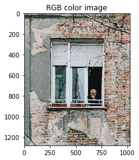

```python
img = cv.imread ('windows.jpeg', cv.IMREAD_COLOR) # Read BGR picture with opencv
rgb_img=img[:,:,::-1] # Convert picture to RGB channel
plt.imshow(rgb_img) # Display picture with matplotlib
plt.title('RGB color image')
plt.show()
```

b. covert RGB image into Lab color system and display each component (L,a,b) as an grey level image

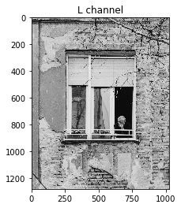

```python
lab_img = cv.cvtColor(rgb_img, cv.COLOR_RGB2Lab) # Convert the RGB image into Lab colour system
L, a, b = cv.split(lab_img) # Split the image to L, a, b channels

# L channel
plt.imshow(L, cmap='gray') # Display each channel with matplotlib
plt.title('L channel')
plt.show()
```

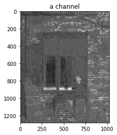

```python
# a channel
plt.imshow(a, cmap='gray')
plt.title('a channel')
plt.show()
```

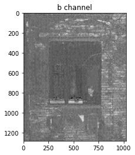

```python
# b channel
plt.imshow(b, cmap='gray')
plt.title('b channel')
plt.show()
```

c. Compute the spatial derivatives of the luminance component L in the horizontal and vertical direction using convolution by the derivatives of Gaussian filter. Display each these derivatives as grey level images.

```python
# Here the Sobel derivative is adopted in both of the horizontal and vertical direction.
# Compute the spatial derivatives.
horizontal_derivative = cv.Sobel (L,cv.CV_64F,1,0,ksize=5) # set the kernel size as 5
veritical_derivative  = cv.Sobel (L,cv.CV_64F,0,1,ksize=5) # set the kernel size as 5
```

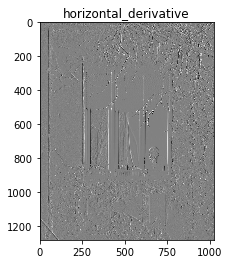

```python
# Display the horizontal derivative as grey level image
plt.imshow(horizontal_derivative, cmap = 'gray')
plt.title('horizontal_derivative')
plt.show()
```

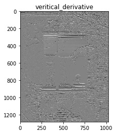

```python
# Display the vertical derivative as grey level image
plt.imshow(veritical_derivative, cmap = 'gray')
plt.title('veritical_derivative')
plt.show()
```

d. Compute a 2D histogram with the chrominance component (a,b) and display the histogram as a grey image (heat map) and/or as a 3D surface (bar plot)

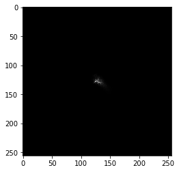

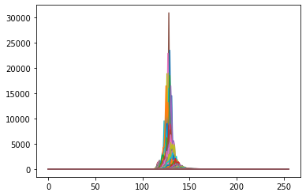

```python
#Compute 2D histogram with OpenCV
# And display it as a grey image.
histogram2d = cv.calcHist([lab_img], [1, 2], None, [256, 256], [0, 256, 0, 256])
#channels=[1,2] dealing with a and b, bins=[256, 256] chanel of a and b, range=[0, 256, 0, 256] range of a and b
plt.imshow(histogram2d, interpolation = 'nearest', cmap = 'gray')
plt.show()

plt.plot(histogram2d,label=a*b)
plt.show()
```

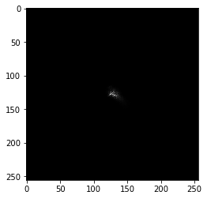

```python
# Method2. Compute 2D histogram with Numpy
# And display it as a grey image.
histogram2d, xbins, ybins = np.histogram2d(a.ravel(),b.ravel(),[256,256],[[0,256],[0,256]])
plt.imshow(histogram2d, interpolation = 'nearest', cmap = 'gray')
plt.show()
```

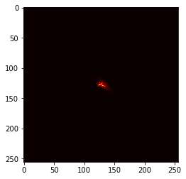

```python
#display the histogram as a grey image (heat map)
plt.imshow(histogram2d, interpolation = 'nearest', cmap = 'hot')
plt.show()
```

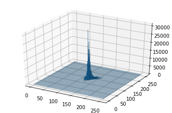

```python
#display the histogram as a 3D surface (bar plot)

# Construct arrays for the anchor positions of the 3D bar plot.
histogram2d, xbins, ybins = np.histogram2d(a.ravel(),b.ravel(),[256,256],[[0,256],[0,256]])

xpos, ypos = np.meshgrid(xbins[:-1] + 0.25, ybins[:-1] + 0.25, indexing="ij")
xpos = xpos.ravel()
ypos = ypos.ravel()
zpos = 0

# Construct arrays with the dimensions for the bars.
dx = dy = 0.5 * np.ones_like(zpos)
dz = histogram2d.ravel()

fig = plt.figure()
axes = fig.add_subplot(111, projection='3d')
axes.bar3d(xpos, ypos, zpos, dx, dy, dz, zsort='average')
plt.show()
```

e. Using a part of the image to compute a 2D histogram model with the chrominance component (a,b), compute a back projection map with this model histogram in the target image.

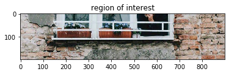

```python
# roi (region of interest) is the part cropped from the original image.
rgb_roi = rgb_img[800:1000,100:1000]
plt.imshow(rgb_roi) # Display picture with matplotlib
plt.title('region of interest')
plt.show()
```

```python
# Convert the cropped part into Lab color system.
lab_roi = cv.cvtColor(rgb_roi, cv.COLOR_BGR2Lab)
# Find the 2D histogram of roi using calcHist, which can be done with np.histogram2d also (as we did above).
hist_roi  = cv.calcHist([lab_roi],[1, 2], None, [256, 256], [0, 255, 0, 256])
# Normalize the 2D histogram.
cv.normalize(hist_roi, hist_roi, 0, 255, cv.NORM_MINMAX)
```

```
array([[0., 0., 0., ..., 0., 0., 0.],
       [0., 0., 0., ..., 0., 0., 0.],
       [0., 0., 0., ..., 0., 0., 0.],
       ...,
       [0., 0., 0., ..., 0., 0., 0.],
       [0., 0., 0., ..., 0., 0., 0.],
       [0., 0., 0., ..., 0., 0., 0.]], dtype=float32)
```

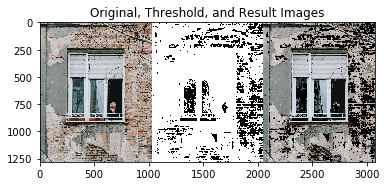

```python
#Calculate the back projection of the 2D histogram.
dst = cv.calcBackProject([lab_img], [1,2], hist_roi, [0,256,0,256], 1)

# Convolute with circular disc and conbine the decentralized spot
disc = cv.getStructuringElement(cv.MORPH_ELLIPSE,(5,5))
dst = cv.filter2D(dst, -1, disc, dst)

# Get threshold and bit for finding roi in the original image.
ret, thresh = cv.threshold(dst, 50, 255, 0)

# Get the threshold image for 3 channels.
thr_img = cv.merge((thresh, thresh, thresh))

# Calculate with bits image.
res_img= cv.bitwise_and(img, thr_img)
res_img = cv.cvtColor(res_img, cv.COLOR_BGR2RGB)

# Stack the original image, threshold image, and result image together.
# To figure out the performance of finding the roi with back projection.
res_stacked = np.hstack((rgb_img, thr_img, res_img))

# Display the final production.
plt.imshow(res_stacked)
plt.title('Original, Threshold, and Result Images')
plt.show()
```

f. Perform histogram equalization using 1D histogram using the luminance L computed in 1.b. Display the resulting image with enhanced contrast

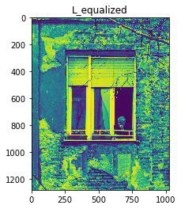

```python
# Apply histogram equalization using 1D histogram using the L channel and dispaly the resulted image.
L_equalized = cv.equalizeHist(L)
plt.imshow(L_equalized)
plt.title('L_equalized')
plt.show()
```

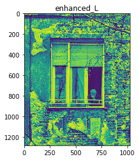

```python
# Enhance the contrast and display the resulted image

# Contrast Limited Adaptive Histogram Equalization (CLAHE) is adopted to reach the goal.
clahe = cv.createCLAHE(clipLimit=3.0, tileGridSize=(8,8))
enhanced_L = clahe.apply(L)
plt.imshow(enhanced_L)
plt.title('enhanced_L')
plt.show()
```

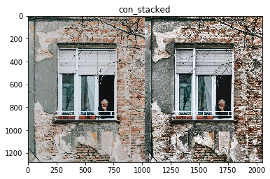

```python
# We can also combine the enhanced L with a, b to figure out the change.
con_img = cv.merge((enhanced_L, a, b))
con_img = cv.cvtColor(con_img, cv.COLOR_LAB2RGB)
con_stacked = np.hstack((rgb_img, con_img))
plt.imshow(con_stacked)
plt.title('con_stacked')
plt.show()
```

g. Evaluate the performance of these techniques with histograms (i.e. illustrate when it works, and when it does not work)

Answer:

1. Spatial Derivatives help us find edges in horizontal and vertical directions. It works well when there are clear and distinct horizontal or vertical edges in the target image. And the resulted derivative image becomes blurry if there are not such edges.
2. 2D histogram and back projection help us figure out the characters of a region of interest, thus we can search the target region in the original image（ROI）. It works well when the character of the ROI is unique in the target image. And the performance mainly depends on the color.
3. The contrast limited adaptive histogram equalization helps us apply a histogram equalization on the L channel and enhance the contrast. It can also be used to enchance the contract of original image when we merge the converted L channel with a, b channels.

# 2. PCA

main references:

```
https://blog.csdn.net/qq_31584013/article/details/88653802
https://blog.csdn.net/Rookiegrowth/article/details/86077463
https://www.jianshu.com/p/b9f2c92dfeaa
https://doi.org/10.1109/34.598227
https://scikit-learn.org/stable/modules/generated/sklearn.decomposition.PCA.html
https://doi.org/10.1109/34.598227
```

```python
mndata = MNIST('mnistdata')
# Load MNIST trainset.
images, labels = mndata.load_training()
# Load MNIST testset.
test_images, test_labels = mndata.load_testing()
```

```python
# Collect traing samples of '5'.
images_five = []
for i in range(0, len(images)):
    if labels[i] == 5:
        images_five.append(images[i])
images_five = np.array(images_five)# outcome of mnist is 2bits
```

```python
# Collect test samples of '5'.
test_images_five = []
for i in range(0, len(test_images)):
    if test_labels[i] == 5:
        test_images_five.append(test_images[i])
test_images_five = np.array(test_images_five)
```

a. Compute the mean image and principal components for a set of images (e.g. use the training images of ‘5’ in the mnist dataset). Display the mean image and the first 2 principal components (associated with the highest eigenvalues).

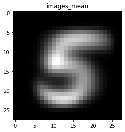

```python
# Compute the mean image for the set of '5' in the mnist training dataset.
images_mean = images_five[0]
for i in range(len(images_five)):
    images_mean = images_mean + images_five[i]
images_mean = images_mean / len(images_five)

# Display the mean image.
images_mean= images_mean.reshape((28, 28))#mnist is array of 1*784
plt.imshow(images_mean, cmap='gray')
plt.title('images_mean')
plt.show()
```

```python
# Apply PCA and compute the first 2 principal components.
pca = PCA(n_components=2)
images_five = np.transpose(images_five)
components = pca.fit_transform(images_five)
components = np.transpose(components)
```

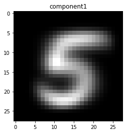

```python
# Display the first component.
component1= components[0].reshape((28, 28))
plt.imshow(component1, cmap='gray')
plt.title('component1')
plt.show()
```

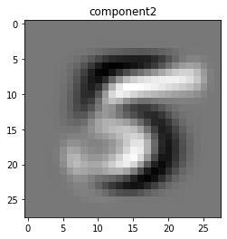

```python
# Display the second component.
component2= components[1].reshape((28, 28))
plt.imshow(component2, cmap='gray')
plt.title('component2')
plt.show()
```

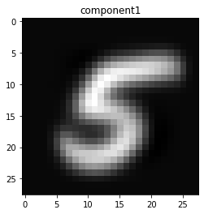

```python
component3=component1+component2
plt.imshow(component3, cmap='gray')
plt.title('component1')
plt.show()
```

b. Compute and display the reconstructions of a test image using the mean image and with p principal components associated with the p highest eigenvalues (e.g. Fig 10.12) with p=10 and p=50.

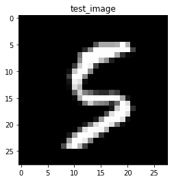

```python
# Randomly choose a test image and display it.
index = random.randrange(0, len(test_images_five))
test_image = test_images_five[index]
test_image = test_image.reshape((28, 28))
plt.imshow(test_image, cmap='gray')
plt.title('test_image')
plt.show()
```

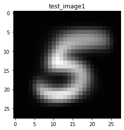

```python
# The mean image plus the first p principal components as a reconstruction (p=10).
pca = PCA(n_components=10)
components = pca.fit_transform(images_five)
components = np.transpose(components)

coefficients = pca.singular_values_

test_image1 = coefficients[0] * components[0]
for i in range(1, len(components)):
    test_image1 = test_image1 + coefficients[i] * components[i]

test_image1 = test_image1.reshape((28, 28))
test_image1 = test_image1 + images_mean

plt.imshow(test_image1, cmap='gray')
plt.title('test_image1')
plt.show()
```

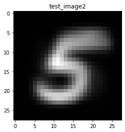

```python
# The mean image plus the first p principal components as a reconstruction (p=50).
pca = PCA(n_components=50)
components = pca.fit_transform(images_five)
components = np.transpose(components)

coefficients = pca.singular_values_

test_image2 = coefficients[0] * components[0]
for i in range(1, len(components)):
    test_image2 = test_image2 + coefficients[i] * components[i]

test_image2 = test_image2.reshape((28, 28))
test_image2 = test_image2 + images_mean

plt.imshow(test_image2, cmap='gray')
plt.title('test_image2')
plt.show()
```

c. Read https://doi.org/10.1109/34.598227 ‘Probabilistic visual learning for object representation’ (PAMI1997). Compute and display a DFFS (distance-from feature-space) and SSD (sum-of-square-differences) heat maps for detection using your PCA representation of a MNIST number. For the test image, use a composite image made of MNIST test images (see example below).

```python
# Load the composite image.
com_img = cv.imread('compositeImage.jpg', cv.IMREAD_GRAYSCALE)
com_img.shape
```

```
(360, 480)
```

```python
# Calculate the DFFS image with the PCA representation (p=10)

# For simplicity, we do not apply padding operation on the composite image.
#eigenspace decomposition
heat_width = com_img.shape[0] - 28 + 1
heat_height = com_img.shape[1] - 28 + 1
dffs_heat = np.zeros((heat_width, heat_height))

#to find the target object, we need a slide window to slide along this composite image.
for i in range(0, heat_width):
    for j in range(0, heat_height):
        img_x_start = i
        img_x_end = i + 28
        img_y_start = j
        img_y_end = j + 28
        img_cropped = com_img[img_x_start:img_x_end, img_y_start:img_y_end]
        residual = img_cropped - test_image1#DFFS=y-(averagex+reconstruction),using PCA representation of a MNIST number
        dffs_heat[i,j] = np.linalg.norm(residual)
```

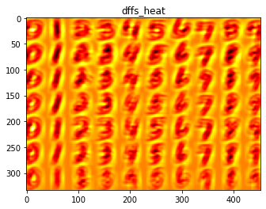

```python
# Display the resulted DFFS image as a heatmap.
plt.imshow(dffs_heat, cmap='hot',interpolation='nearest')
plt.title('dffs_heat')
plt.show()
```

```python
# Calculate the SSD image with the mean image.

# For simplicity, we do not apply padding operation on the composite image.
heat_width = com_img.shape[0] - 28 + 1
heat_height = com_img.shape[1] - 28 + 1
ssd_heat = np.zeros((heat_width, heat_height))


#to find the target object, we need a slide window to slide along this composite image.
for i in range(0, heat_width):
    for j in range(0, heat_height):
        img_x_start = i
        img_x_end = i + 28
        img_y_start = j
        img_y_end = j + 28
        img_cropped = com_img[img_x_start:img_x_end, img_y_start:img_y_end]
        residual = img_cropped - images_mean#SSD=y-averagex
        ssd_heat[i,j] = np.linalg.norm(residual)
```

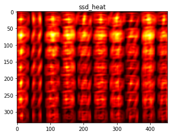

```python
# Display the resulted SSD image as a heatmap.
plt.imshow(ssd_heat, cmap='hot')
plt.title('ssd_heat')
plt.show()
```

d. Evaluate the performance of SSD and DFFS (i.e. illustrate when it works, and when it does not work).

Answer：

1. The above results show that the performance of SSD is worse that DFFS. Although both of the techiques can not detect '5' perfectly, they can assist detecting number obejcts in the composite image (to some extent).
2. It seems that the SSD perform better when recognitzing a template that the target object in the composite image almost is the same as the template. And the DFFS will reach a robust performance when the appearance of the target object change according to relative factors such as one's different writing style.